# BANA 7025 - Data Wrangling Project

Group 7

| **Members** : Soumi Giri, Arvind Kurumbal Radhakrishnan, Samreen Pathan, Saksham Bhutani, Divyanshu Kumar |
| --- |

# Hotel Data Project

## 1. Introduction

### 1.1 Problem Statement

Tourism has always being a very lucrative industry worth millions of dollars in US alone. Due to the pandemic in 2020 the tourism industry was one of the worst impacted sectors. But as the world is moving towards a new normal we are taking a look at what strategies can be devised to improve booking rates for hotels as well as improve the hotel revenues.

To infer the different marketing and tactical strategies to improve hotel bookings we are taking a look at the `hotels` data provided to us. The data gives us details of hotel bookings from 1st of July of 2015 to the 31st of August 2017, including bookings that effectively arrived and bookings that were canceled. We have 2 hotel types from the same chain in our data *Resort Hotel* and *City Hotel* for which we have details regarding bookings like arrival dates, family members, type of room, booking medium etc. Both the hotels are located in Portugal, The *Resort Hotel* in resort region in Algarve and the *City Hotel* in Lisbon. Using the data we are trying to identify actionable strategies which would help us increase the booking rates of the hotels while also trying to identify the customer preferences.

### 1.2 Approach

We have a host of information at our disposal including arrival date information, duration of stay, customer demographics (number of adults/children), booking channel information (travel agents/tour operators details), customer historic behavior (booking changes/cancellations) etc. These features will be analyzed against number of bookings/Average Daily Rate/number of cancellations. This data exploration exercise should help:

- A person with little context of the field gain insights on trends in the hotel industry
- Serve as good starting point for someone looking to enter the industry
- Help existing players modify their market strategies

### 1.3 Analytical Steps

Following were the steps taken:

1. **Identify features**: Analyze all features and identify key features on the basis of the insights to be generated.
2. **Clean data**: Diagnose and treat any problems in the data on a per feature basis.
3. **Exploratory Data Analysis**:
   - *Summarize*: Understand distribution of variables, use summary statistics like mean, median etc.
   - *Visualize*: Use visualizations to better understand the structure and distributions across variables.
4. **Generate hypothesis**: On the basis of EDA formulate hypothesis using key features
5. **Test hypothesis**: Test generated hypothesis to check validity of claims
6. **Conclusion**: Infer result of hypothesis test and generate insights in accordance with the results of the testing

### 1.4 Benefits of the Analysis

This analysis will give the management team of the Portugal based hotel chain, a good understanding of bookings and cancellation trends over time and across other variables like customer demographics and services provided by the hotel. The insights can also be considered as a generalized trend for the industry across similar geographical regions. In addition to gaining an understanding of prevalent trends, this analysis can also be the foundation for design of marketing and operational strategies.

## 2. Packages Required

### 2.1 Packages Used in Analysis

The following packages are loaded to conduct our analysis

```r
library(tidyverse)
library(ggplot2)
library(dplyr)
library(knitr)
library(DT)
library(plotly)
library(viridis)
library(wordcloud)
library(RColorBrewer)
library(forcats)
```

### 2.2 Package Description

The following packages are used for our analysis:

1. **dplyr** - dplyr is a grammar of data manipulation, providing a consistent set of verbs that helps us solve the most common data manipulation challenges.
2. **ggplot2** - ggplot2 is a system for declaratively creating graphics, to help us visualize our data. We provide the data, tell ggplot2 how to map variables to aesthetics, what graphical primitives to use, and it takes care of the details.
3. **knitr** - This is an alternative tool to Sweave with a more flexible design and new features like caching and finer control of graphics. This help us incorporate more dynamic graphic representation (example: table views) for our report.
4. **DT** - R data objects (matrices or data frames) can be displayed as tables on HTML pages, and DataTables provides filtering, pagination, sorting, and many other features in the tables.
5. **plotly** - Plotly is an R package for creating interactive web-based graphs via plotly’s JavaScript graphing library, plotly.js
6. **viridis** - Provides color scales to make plots that are pretty, better represent data, easier to read by those with colorblindness, and prints well in gray scale.
7. **wordcloud** - Generates wordcloud in R
8. **RColorBrewer** - RColorBrewer is an R packages that uses the work from http://colorbrewer2.org/ to help you choose sensible colour schemes for figures in R. The colors are split into three group, sequential, diverging, and qualitative.
9. **forcats** - The goal of the forcats package is to provide a suite of tools that solve common problems with factors, including changing the order of levels or the values. Some examples include: fct_reorder() : Reordering a factor by another variable.

## 3. Data Preparation

### 3.1 Source of Data

Data used for our analysis can be found [here](https://github.com/rfordatascience/tidytuesday/blob/master/data/2020/2020-02-11/readme.md).

### 3.2 Data Description

The data format is mixed (raw and processed).The data is comprised of two types of hotels i.e. Resort Hotel (40,060 obs) located in Algarve and City Hotel (79,330 obs) located in Lisbon. The data was collected between July 1st, 2015 and August 31st, 2017. Since the data is real, hotel name and any customer identifiers are not included.The data has 32 variables which can be classified into the following categories:

1. **Time Based Features** - Gives us when a booking was made, when the booking party arrived and how long the stay was. ArrivalDateDayOfMonth, ArrivalDateMonth, ArrivalDateWeekNumber, ArrivalDateYear, LeadTime etc
2. **Customer Demography Features** - Characteristics of the customers who had made the booking. Adults, Babies, Children, Country etc
3. **Booking Profile** - These columns provide us a specific characteristics of a customer’s booking. AssignedRoomType, BookingChanges, DaysInWaitingList, IsRepeatedGuest etc
4. **Market Channels** - Different channels through which the reservation was made. Agent, Company, DistributionChannel, MarketSegment.
5. **Hotel Services** - Different additional services that the hotel provides. meal, required_car_parking_spaces, total_of_special_requests.

The data was collected for educational purposes and is focusing on revenue management. Data was obtained directly from the hotels’ PMS databases’ servers.The PMS assured no missing data exists in its database tables. However, in some categorical variables like Agent or Company, “NULL” is presented as one of the categories. This should not be considered a missing value, but rather as “not applicable”. For example, if a booking “Agent” is defined as “NULL” it means that the booking did not came from a travel agent.

The objective of the data is to give a better understanding of this market as multiple things can be explored by this data like customer segmentation, seasonality, cancellation prediction, etc.

A detailed data dictionary view - [Link](https://github.com/rfordatascience/tidytuesday/blob/master/data/2020/2020-02-11/readme.md#data-dictionary).

### 3.3 Data Importing and Cleaning

```r
hotels <- read.csv('https://raw.githubusercontent.com/rfordatascience/tidytuesday/master/data/2020/2020-02-11/hotels.csv')
```

#### 3.3.1 Understanding Data Structure

In our `hotels` data, we have 13 character variables, 18 numeric variables and 1 date variable.

```r
str(hotels)
```

```
## 'data.frame':    119390 obs. of  32 variables:
##  $ hotel                         : chr  "Resort Hotel" "Resort Hotel" "Resort Hotel" "Resort Hotel" ...
##  $ is_canceled                   : int  0 0 0 0 0 0 0 0 1 1 ...
##  $ lead_time                     : int  342 737 7 13 14 14 0 9 85 75 ...
##  $ arrival_date_year             : int  2015 2015 2015 2015 2015 2015 2015 2015 2015 2015 ...
##  $ arrival_date_month            : chr  "July" "July" "July" "July" ...
##  $ arrival_date_week_number      : int  27 27 27 27 27 27 27 27 27 27 ...
##  $ arrival_date_day_of_month     : int  1 1 1 1 1 1 1 1 1 1 ...
##  $ stays_in_weekend_nights       : int  0 0 0 0 0 0 0 0 0 0 ...
##  $ stays_in_week_nights          : int  0 0 1 1 2 2 2 2 3 3 ...
##  $ adults                        : int  2 2 1 1 2 2 2 2 2 2 ...
##  $ children                      : int  0 0 0 0 0 0 0 0 0 0 ...
##  $ babies                        : int  0 0 0 0 0 0 0 0 0 0 ...
##  $ meal                          : chr  "BB" "BB" "BB" "BB" ...
##  $ country                       : chr  "PRT" "PRT" "GBR" "GBR" ...
```

[output cut: 18 more lines]

Below we observe the summary statistics for all ournumerics columns.

```r
num_cols <- unlist(lapply(hotels, is.numeric))

summary(hotels[, num_cols])
```

```
##   is_canceled       lead_time   arrival_date_year arrival_date_week_number
##  Min.   :0.0000   Min.   :  0   Min.   :2015      Min.   : 1.00
##  1st Qu.:0.0000   1st Qu.: 18   1st Qu.:2016      1st Qu.:16.00
##  Median :0.0000   Median : 69   Median :2016      Median :28.00
##  Mean   :0.3704   Mean   :104   Mean   :2016      Mean   :27.17
##  3rd Qu.:1.0000   3rd Qu.:160   3rd Qu.:2017      3rd Qu.:38.00
##  Max.   :1.0000   Max.   :737   Max.   :2017      Max.   :53.00
##
##  arrival_date_day_of_month stays_in_weekend_nights stays_in_week_nights
##  Min.   : 1.0              Min.   : 0.0000         Min.   : 0.0
##  1st Qu.: 8.0              1st Qu.: 0.0000         1st Qu.: 1.0
##  Median :16.0              Median : 1.0000         Median : 2.0
##  Mean   :15.8              Mean   : 0.9276         Mean   : 2.5
##  3rd Qu.:23.0              3rd Qu.: 2.0000         3rd Qu.: 3.0
##  Max.   :31.0              Max.   :19.0000         Max.   :50.0
##
##      adults          children           babies          is_repeated_guest
##  Min.   : 0.000   Min.   : 0.0000   Min.   : 0.000000   Min.   :0.00000
##  1st Qu.: 2.000   1st Qu.: 0.0000   1st Qu.: 0.000000   1st Qu.:0.00000
##  Median : 2.000   Median : 0.0000   Median : 0.000000   Median :0.00000
##  Mean   : 1.856   Mean   : 0.1039   Mean   : 0.007949   Mean   :0.03191
##  3rd Qu.: 2.000   3rd Qu.: 0.0000   3rd Qu.: 0.000000   3rd Qu.:0.00000
##  Max.   :55.000   Max.   :10.0000   Max.   :10.000000   Max.   :1.00000
##                   NA's   :4
##  previous_cancellations previous_bookings_not_canceled booking_changes
##  Min.   : 0.00000       Min.   : 0.0000                Min.   : 0.0000
##  1st Qu.: 0.00000       1st Qu.: 0.0000                1st Qu.: 0.0000
##  Median : 0.00000       Median : 0.0000                Median : 0.0000
##  Mean   : 0.08712       Mean   : 0.1371                Mean   : 0.2211
##  3rd Qu.: 0.00000       3rd Qu.: 0.0000                3rd Qu.: 0.0000
##  Max.   :26.00000       Max.   :72.0000                Max.   :21.0000
##
##  days_in_waiting_list      adr          required_car_parking_spaces
##  Min.   :  0.000      Min.   :  -6.38   Min.   :0.00000
##  1st Qu.:  0.000      1st Qu.:  69.29   1st Qu.:0.00000
##  Median :  0.000      Median :  94.58   Median :0.00000
##  Mean   :  2.321      Mean   : 101.83   Mean   :0.06252
##  3rd Qu.:  0.000      3rd Qu.: 126.00   3rd Qu.:0.00000
##  Max.   :391.000      Max.   :5400.00   Max.   :8.00000
##
##  total_of_special_requests
##  Min.   :0.0000
##  1st Qu.:0.0000
##  Median :0.0000
##  Mean   :0.5714
##  3rd Qu.:1.0000
##  Max.   :5.0000
##
```

#### 3.3.2 Understanding Data Distribution

**Days in waiting list**

We observe that *96%* bookings were confirmed within a day.

**Booking Changes**

We observe that for *Booking Changes*, *95%* of the values lie between 0 and 2, *99%* between 0 and 4. There are only 267 (0.2%) such cases where there are more than 4 booking changes.

**Lead Time**

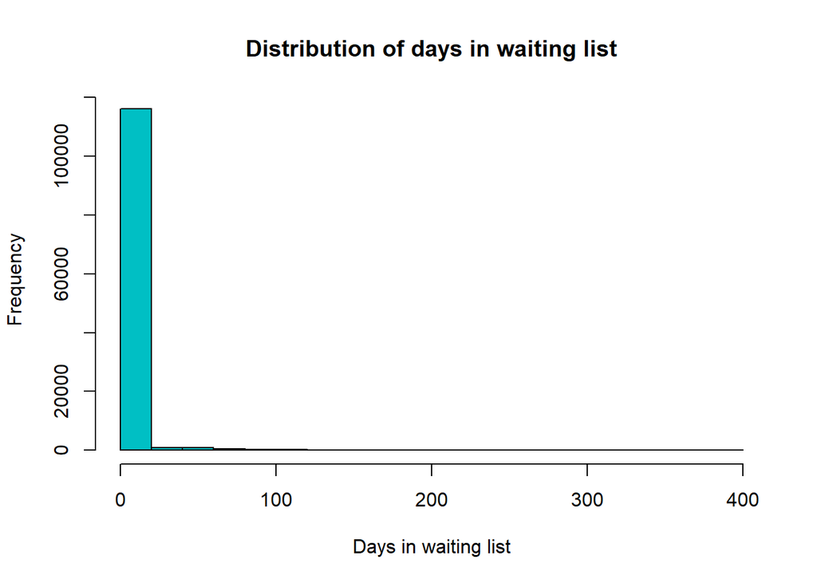

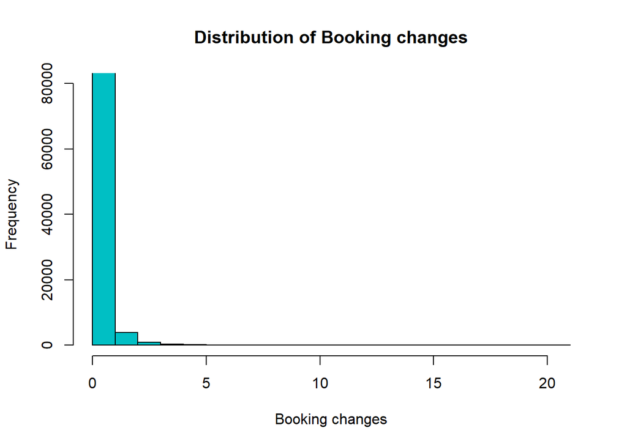

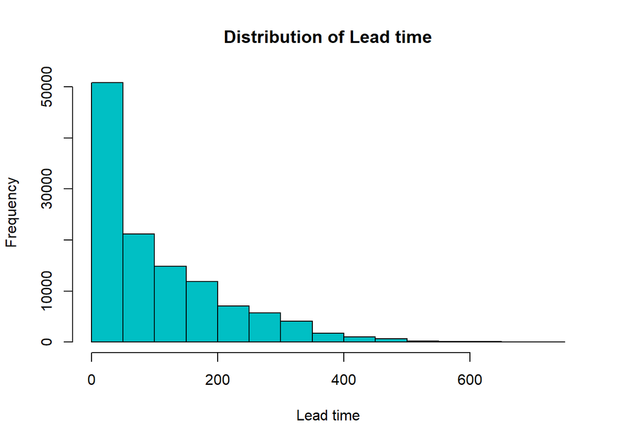

```r
hist(hotels$days_in_waiting_list,
     main="Distribution of days in waiting list",
     xlab = "Days in waiting list",
     col = "#00BFC4")
hist(hotels$booking_changes,
     main="Distribution of Booking changes",
     xlab = "Booking changes",
     ylim=c(0,80000),
     col = "#00BFC4")
hist(hotels$lead_time,
     main="Distribution of Lead time",
     xlab = "Lead time",
     col = "#00BFC4")
```

**Previous cancellations**

We observe that for *Previous cancellations*, *99%* of the values lie between 0 and 1. There are only *317* such cases where there are more than 2 previous cancellations.

**Previous bookings not canceled**

We observe that for *Previous bookings not canceled*, *99%* of the values lie between 0 and 7. There are only *552* such cases where there are more than 7 non-cancellations.

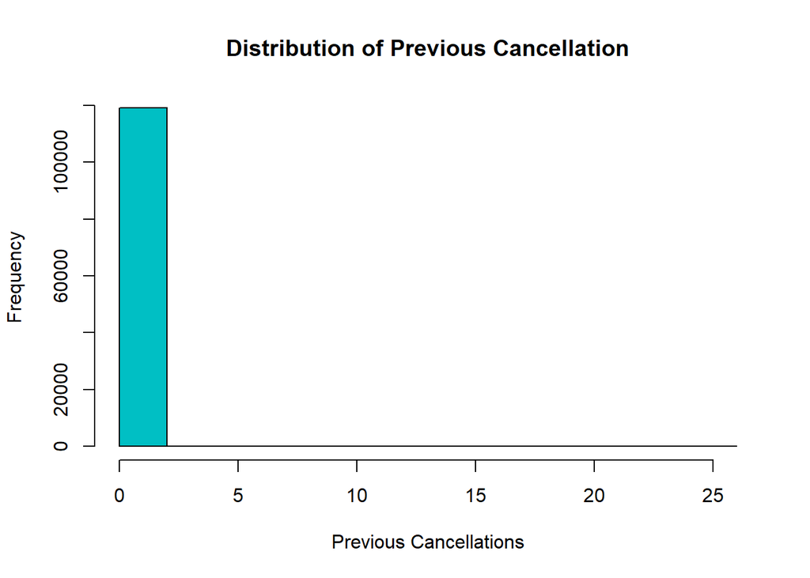

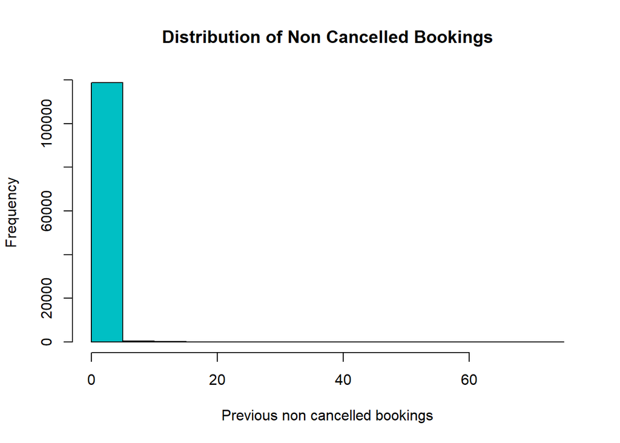

```r
#Understand variable and visually inspect
hist(hotels$previous_cancellations,
     main="Distribution of Previous Cancellation",
     xlab = "Previous Cancellations",
     col = "#00BFC4")
hist(hotels$previous_bookings_not_canceled,
     main="Distribution of Non Cancelled Bookings",
     xlab = "Previous non cancelled bookings",
     col = "#00BFC4")
```

#### 3.3.3 NULL/NA Identification and Treatment

```r
colSums(is.na(hotels))
```

```
##                          hotel                    is_canceled
##                              0                              0
##                      lead_time              arrival_date_year
##                              0                              0
##             arrival_date_month       arrival_date_week_number
##                              0                              0
##      arrival_date_day_of_month        stays_in_weekend_nights
##                              0                              0
##           stays_in_week_nights                         adults
##                              0                              0
##                       children                         babies
##                              4                              0
##                           meal                        country
##                              0                              0
##                 market_segment           distribution_channel
##                              0                              0
##              is_repeated_guest         previous_cancellations
##                              0                              0
## previous_bookings_not_canceled             reserved_room_type
##                              0                              0
##             assigned_room_type                booking_changes
##                              0                              0
##                   deposit_type                          agent
##                              0                              0
##                        company           days_in_waiting_list
##                              0                              0
##                  customer_type                            adr
##                              0                              0
##    required_car_parking_spaces      total_of_special_requests
##                              0                              0
##             reservation_status        reservation_status_date
##                              0                              0
```

As mentioned earlier for the agent and company columns, the string “NULL” indicates that the booking wasn’t made through an agent/company. Below are the summary numbers for such bookings.

```r
length(hotels$agent[hotels$agent == "NULL"])
```

```
## [1] 16340
```

```r
length(hotels$company[hotels$company == "NULL"])
```

```
## [1] 112593
```

Agent column has 16340 (~13%) NULLs and Company has 112593 (~94%) NULLs. This indicates that these bookings were not made via any agent or company.

Rest of the columns do not have any NULLs or missing values.

#### 3.3.4 Checking for Outliers

We check for outliers for the following numeric variables

**ADR**

We observe that for *ADR*, all values lie within 550 except one which is way greater, 5400. We are going with an assumption that this is a data entry issue and treating it as an outlier, replacing it by 0.

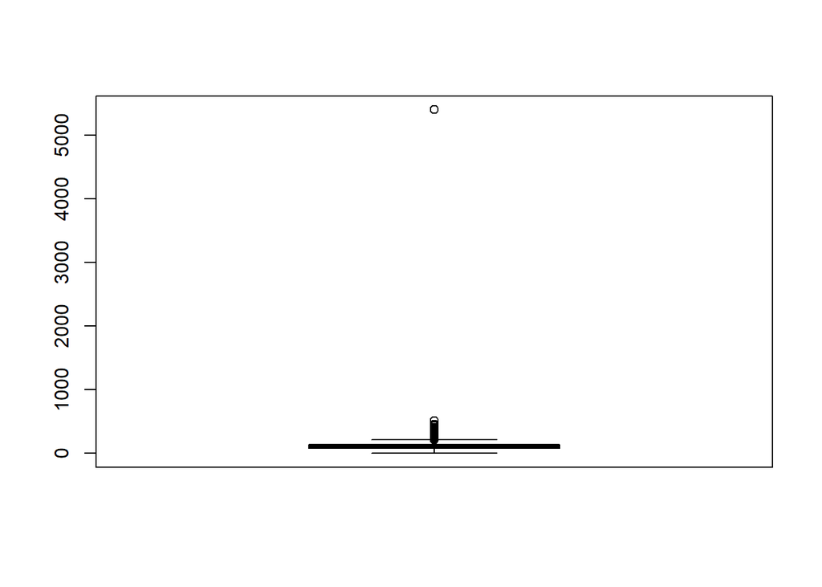

```r
boxplot(hotels$adr)
```

After treating the outlier the distribution looks like:

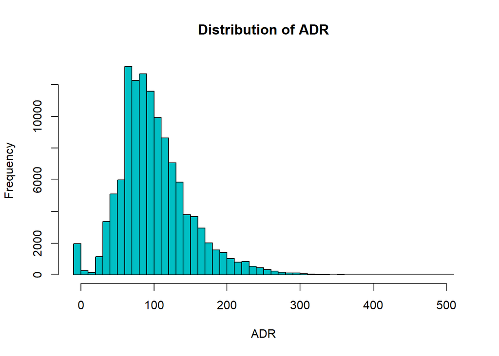

```r
hotels$adr[hotels$adr=="5400"] <- 0
hist(hotels$adr,
     main="Distribution of ADR",
     xlab = "ADR",
     col = "#00BFC4", breaks = 50)
```

### 3.4 Final Dataset

```r
datatable(hotels[1:100,], caption = 'Table 1: Clean and tidy data.')
```

|  | hotel | is_canceled | lead_time | arrival_date_year | arrival_date_month | arrival_date_week_number | arrival_date_day_of_month | stays_in_weekend_nights | stays_in_week_nights | adults | children | babies | meal | country | market_segment | distribution_channel | is_repeated_guest | previous_cancellations | previous_bookings_not_canceled | reserved_room_type | assigned_room_type | booking_changes | deposit_type | agent | company | days_in_waiting_list | customer_type | adr | required_car_parking_spaces | … |
| --- | --- | --- | --- | --- | --- | --- | --- | --- | --- | --- | --- | --- | --- | --- | --- | --- | --- | --- | --- | --- | --- | --- | --- | --- | --- | --- | --- | --- | --- | --- |
| 1 | Resort Hotel | 0 | 342 | 2015 | July | 27 | 1 | 0 | 0 | 2 | 0 | 0 | BB | PRT | Direct | Direct | 0 | 0 | 0 | C | C | 3 | No Deposit | NULL | NULL | 0 | Transient | 0 | 0 | … |
| 2 | Resort Hotel | 0 | 737 | 2015 | July | 27 | 1 | 0 | 0 | 2 | 0 | 0 | BB | PRT | Direct | Direct | 0 | 0 | 0 | C | C | 4 | No Deposit | NULL | NULL | 0 | Transient | 0 | 0 | … |
| 3 | Resort Hotel | 0 | 7 | 2015 | July | 27 | 1 | 0 | 1 | 1 | 0 | 0 | BB | GBR | Direct | Direct | 0 | 0 | 0 | A | C | 0 | No Deposit | NULL | NULL | 0 | Transient | 75 | 0 | … |
| 4 | Resort Hotel | 0 | 13 | 2015 | July | 27 | 1 | 0 | 1 | 1 | 0 | 0 | BB | GBR | Corporate | Corporate | 0 | 0 | 0 | A | A | 0 | No Deposit | 304 | NULL | 0 | Transient | 75 | 0 | … |
| 5 | Resort Hotel | 0 | 14 | 2015 | July | 27 | 1 | 0 | 2 | 2 | 0 | 0 | BB | GBR | Online TA | TA/TO | 0 | 0 | 0 | A | A | 0 | No Deposit | 240 | NULL | 0 | Transient | 98 | 0 | … |
| 6 | Resort Hotel | 0 | 14 | 2015 | July | 27 | 1 | 0 | 2 | 2 | 0 | 0 | BB | GBR | Online TA | TA/TO | 0 | 0 | 0 | A | A | 0 | No Deposit | 240 | NULL | 0 | Transient | 98 | 0 | … |
| 7 | Resort Hotel | 0 | 0 | 2015 | July | 27 | 1 | 0 | 2 | 2 | 0 | 0 | BB | PRT | Direct | Direct | 0 | 0 | 0 | C | C | 0 | No Deposit | NULL | NULL | 0 | Transient | 107 | 0 | … |
| 8 | Resort Hotel | 0 | 9 | 2015 | July | 27 | 1 | 0 | 2 | 2 | 0 | 0 | FB | PRT | Direct | Direct | 0 | 0 | 0 | C | C | 0 | No Deposit | 303 | NULL | 0 | Transient | 103 | 0 | … |
| 9 | Resort Hotel | 1 | 85 | 2015 | July | 27 | 1 | 0 | 3 | 2 | 0 | 0 | BB | PRT | Online TA | TA/TO | 0 | 0 | 0 | A | A | 0 | No Deposit | 240 | NULL | 0 | Transient | 82 | 0 | … |
| 10 | Resort Hotel | 1 | 75 | 2015 | July | 27 | 1 | 0 | 3 | 2 | 0 | 0 | HB | PRT | Offline TA/TO | TA/TO | 0 | 0 | 0 | D | D | 0 | No Deposit | 15 | NULL | 0 | Transient | 105.5 | 0 | … |

[output cut: 90 more lines]

### 3.5 Data Summary

|  | Variable.name | Data.type | Mean | Median |
| --- | --- | --- | --- | --- |
| 1 | lead_time | Numeric | 104 | 69 |
| 2 | stays_in_weekend_nights | Numeric | 0.9276 | 1.0000 |
| 3 | stays_in_week_nights | Numeric | 2.5 | 2.0 |
| 4 | adults | Numeric | 1.856 | 2.000 |
| 5 | children | Numeric | 0.1039 | 0.0000 |
| 6 | babies | Numeric | 0.007949 | 0.000000 |
| 7 | previous_cancellations | Numeric | 0.08712 | 0.00000 |
| 8 | previous_bookings_not_canceled | Numeric | 0.1371 | 0.0000 |
| 9 | booking_changes | Numeric | 0.2211 | 0.0000 |
| 10 | days_in_waiting_list | Numeric | 2.321 | 0.000 |

[output cut: 4 more lines]

[output not shown]

[output cut: 8 more lines]

## 4. Exploratory Data Analysis

From the 32 features present in our data we can broadly classify the features in the following categories:

- **Time based features** - Gives us when a booking was made, when the booking party arrived and how long the stay was
- **Customer Demography features** - Characteristics of the customers who had made the booking. These consists of customer country, family size, etc.
- **Booking Profile features** - These columns provide us a specific characteristics of a customer booking entry. Example - booking duration. stay in weekends, stay in week night, etc.
- **Market Channel features** - Different channels through which the reservation was made. Example - online, corporate, etc.
- **Hotel Services** - Different additional services that the hotel provides. Example - meals, car parking, etc.

### 4.1 Time Based Features

#### 4.1.1 Hypothesis Proposed

We have information regarding the lead time between booking and arrival, arrival date, month, year, duration of stay in the data. Leveraging these, the below hypothesis will be checked:

- Relation between lead time and cancellation, i.e. are bookings that were made a long time back canceled more often or are recently made bookings canceled more often ?
- Relation between lead time and arrival month, i.e. for which months do guests book a long time in advance ?
- Which months/weeks have more bookings ?
- Which days of each month have more bookings ? Are there certain days in certain months where bookings spike, for example the Dec 25 - Jan 1st week? This combined with the previous analysis can be used for dynamic pricing.

On initial exploration of number of bookings across years, we see a big jump between 2015 and 2016 (almost 30%), the jump between 2016 and 2017 is not as much. Please note that here we exclude the cancellations and consider the number of bookings per month to account for the availability of partial data across years. This might not the right approximation as we do not account for seasonality here, for instance maybe hotel bookings might spike during the holiday season and the 2017 data is only till the month of August. This is something we will explore while carrying out the detailed EDAs.

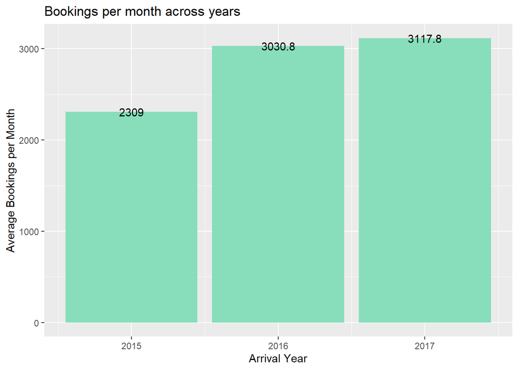

```r
bookings_by_year <-
  hotels %>%
    filter(is_canceled == 0) %>%
      group_by(arrival_date_year) %>%
        summarise(bookings_per_month = n()/n_distinct(arrival_date_month))

ggplot(bookings_by_year,aes(x=arrival_date_year,y=bookings_per_month)) +
  geom_bar(position = "dodge", stat = "identity", fill = "#88ddbb") +
    geom_text(aes(label=paste(round(bookings_per_month,1)))) +
      xlab("Arrival Year") +
        ylab("Average Bookings per Month") +
          ggtitle("Bookings per month across years")
```

#### 4.1.2 Analysis and Trends to Answer Key Questions

##### Hypothesis 1

**Relation between lead time and cancellation, i.e. are bookings that were made a long time back canceled more often or are recently made bookings canceled more often ?**

To test the relationship between lead time and cancellation we use the below plot. We observe that a lot of cancellations are in the first few lead time buckets. But this can be misleading because a lot of the bookings are also in the first few lead time buckets. To get a better understanding we plot % cancellations by lead time bins and here we get the insight that cancellation rates increase as lead time increases. Therefore, people who have made the booking a few days before checking in are less likely to cancel.

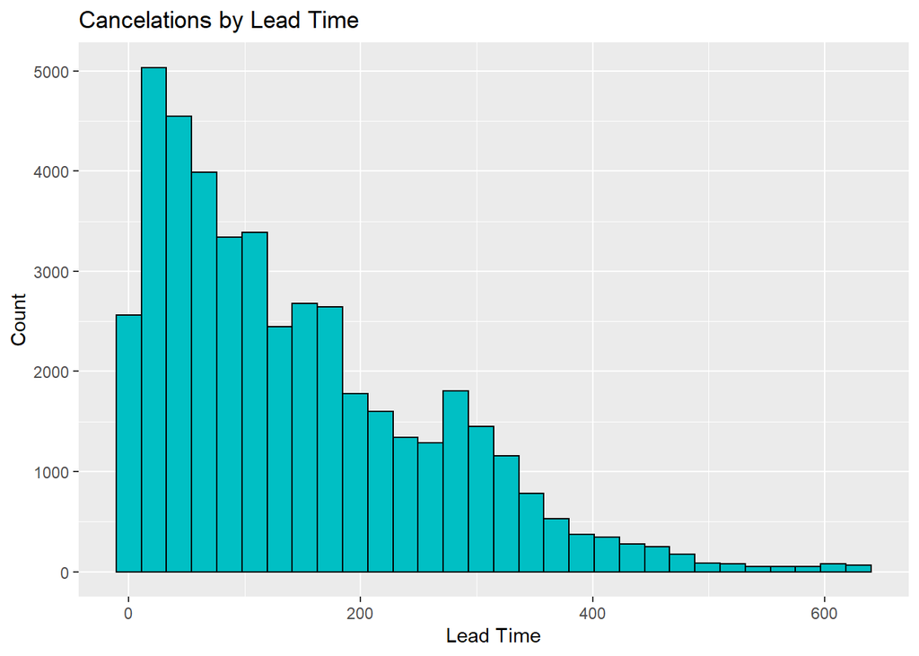

```r
hotels %>%
  filter(is_canceled == 1) %>%
    ggplot(aes(lead_time)) +
      geom_histogram(col="black",fill="#00BFC4") +
        labs(title="Cancelations by Lead Time", x="Lead Time", y="Count")
```

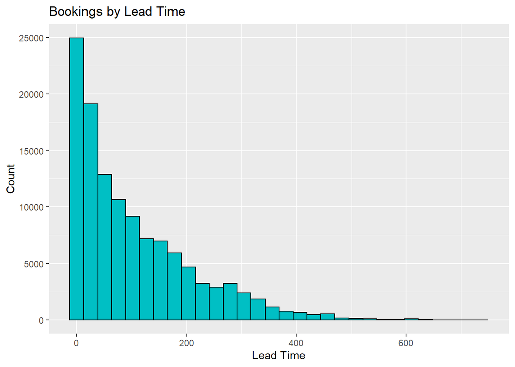

```r
hotels %>%
    ggplot(aes(lead_time)) +
      geom_histogram(col="black",fill="#00BFC4") +
        labs(title="Bookings by Lead Time", x="Lead Time", y="Count")
```

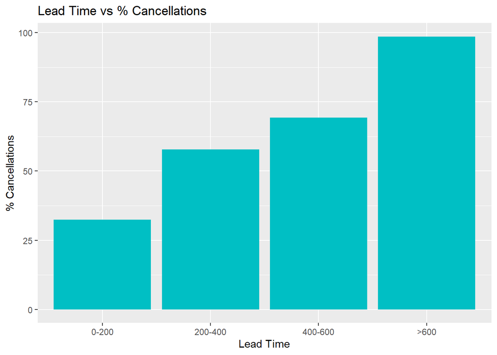

```r
hotels %>%
  mutate(lead_time_bucket = case_when(lead_time >= 0 & lead_time <= 200 ~ "0-200",
                      lead_time > 200 & lead_time <= 400 ~ "200-400",
                      lead_time > 400 & lead_time <= 600 ~ "400-600",
                      lead_time > 600  ~ ">600"),
         lead_time_bucket = fct_relevel(lead_time_bucket,
                                       "0-200","200-400","400-600",">600")) %>%
    group_by(lead_time_bucket) %>%
      summarise(cancellation_percent = sum(is_canceled == 1)/n()) %>%
        ggplot(aes(x=lead_time_bucket,y=cancellation_percent*100)) +
          geom_bar(stat = "identity", fill = "#00BFC4") +
            xlab("Lead Time") +
              ylab("% Cancellations") +
                ggtitle("Lead Time vs % Cancellations")
```

##### Hypothesis 2

**Relation between lead time and arrival month, i.e. for which months do guests book a long time in advance ?**

For bookings which weren’t canceled, the highest average lead time is for bookings where the arrival month is July and June.

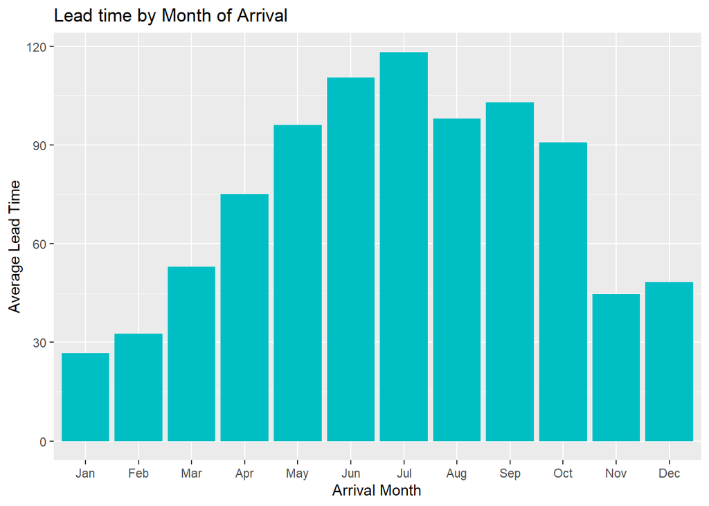

```r
leadtime_by_month <-
  hotels %>%
    filter(is_canceled == 0) %>%
      mutate(arrival_date_month_short = str_sub(arrival_date_month,1,3),
             arrival_date_month_short = fct_relevel(arrival_date_month_short,
                                       "Jan",
                                        "Feb",
                                        "Mar",
                                        "Apr",
                                        "May",
                                        "Jun",
                                        "Jul",
                                        "Aug",
                                        "Sep",
                                        "Oct",
                                        "Nov",
                                        "Dec")) %>%
        group_by(arrival_date_month_short) %>%
          summarise(average_lead_time = mean(lead_time))

ggplot(leadtime_by_month,aes(x=arrival_date_month_short,y=average_lead_time)) +
  geom_bar(position = "dodge", stat = "identity", fill = "#00BFC4") +
    xlab("Arrival Month") +
      ylab("Average Lead Time") +
        ggtitle("Lead time by Month of Arrival")
```

##### Hypothesis 3

**Which months/weeks have more bookings ?**

To check the number of bookings across weeks we plot the below line chart. We can infer that the number of bookings peak around week 20-25 and then again between 40-45. As a follow up we will replicate the same analysis separately for resort hotel and city hotel.

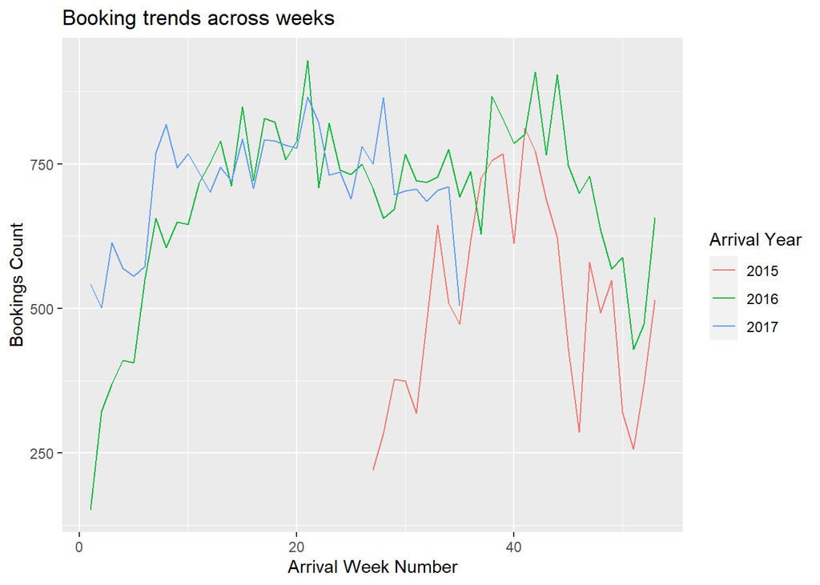

```r
bookings_by_week <-
  hotels %>%
    filter(is_canceled == 0) %>%
      group_by(arrival_date_year,arrival_date_week_number) %>%
        summarise(bookings_per_week = n())

ggplot(bookings_by_week,aes(x=arrival_date_week_number,y=bookings_per_week,
                            group=arrival_date_year)) +
  geom_line(aes(color=as.character(arrival_date_year))) +
    ggtitle("Booking trends across weeks")+
      xlab("Arrival Week Number") +
        ylab("Bookings Count") +
          guides(color=guide_legend(title="Arrival Year"))
```

The trends are slightly different when we filter for resort hotels. When we look at 2017 alone, the peak occurred around week 10. For 2016, the 2 peaks are seen around week 20 and 40, which is consistent with the trend observed in the previous chart.

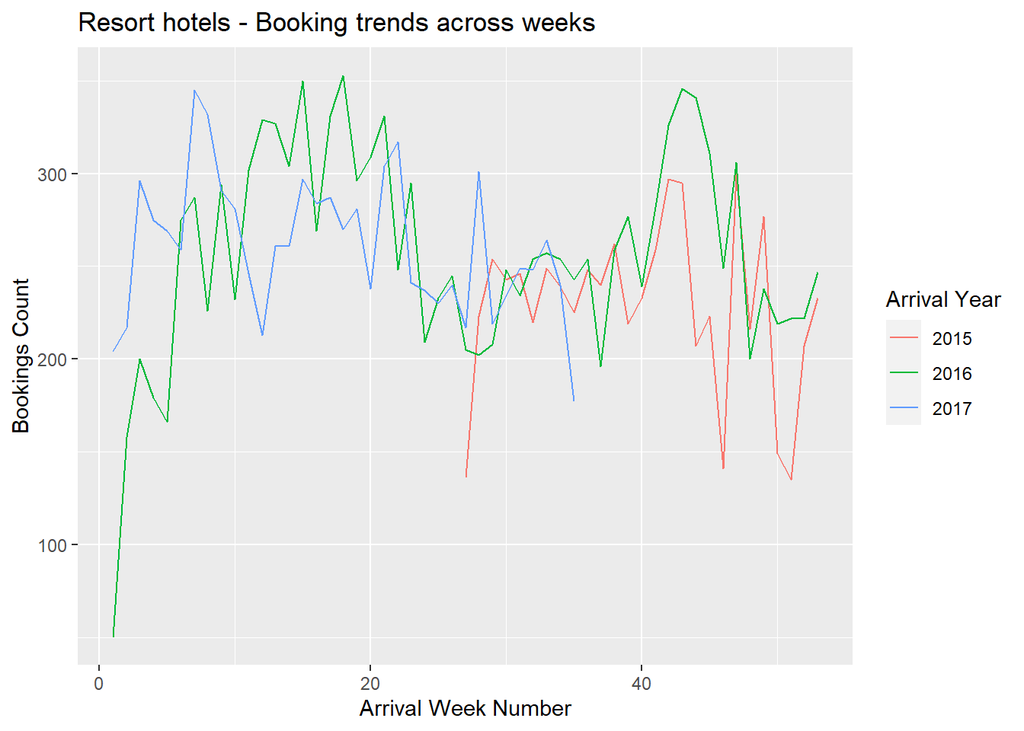

```r
bookings_by_week <-
  hotels %>%
    filter(is_canceled == 0 & hotel == 'Resort Hotel') %>%
      group_by(arrival_date_year,arrival_date_week_number) %>%
        summarise(bookings_per_week = n())

ggplot(bookings_by_week,aes(x=arrival_date_week_number,y=bookings_per_week,
                            group=arrival_date_year)) +
  geom_line(aes(color=as.character(arrival_date_year))) +
    ggtitle("Resort hotels - Booking trends across weeks") +
      xlab("Arrival Week Number") +
        ylab("Bookings Count") +
          guides(color=guide_legend(title="Arrival Year"))
```

City hotel trends are consistent with what we saw in the overall weekly trends, i.e. peaks around weeks 20 and 40.

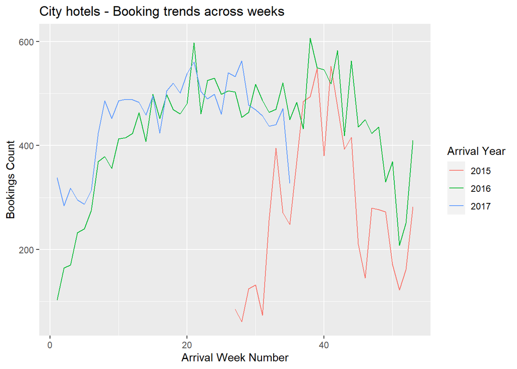

```r
bookings_by_week <-
  hotels %>%
    filter(is_canceled == 0 & hotel == 'City Hotel') %>%
      group_by(arrival_date_year,arrival_date_week_number) %>%
        summarise(bookings_per_week = n())

ggplot(bookings_by_week,aes(x=arrival_date_week_number,y=bookings_per_week,
                            group=arrival_date_year)) +
  geom_line(aes(color=as.character(arrival_date_year))) +
    ggtitle("City hotels - Booking trends across weeks") +
      xlab("Arrival Week Number") +
        ylab("Bookings Count") +
          guides(color=guide_legend(title="Arrival Year"))
```

##### Hypothesis 4

**Which days of each month have more bookings ? Are there certain days in certain months where bookings spike, for example the Dec 25 - Jan 1st week? This combined with the previous analysis can be used for dynamic pricing.**

Below is a heatmap of number of bookings by month vs day. For ease of interpretation we have created a diverging color palette. Below are a few insights:

1. The highest number of bookings are recorded around the 25th of May and June and around the 5th of May and June
2. January seems like a poor performing month, the number of bookings haven’t crossed 150 on even a single day in January

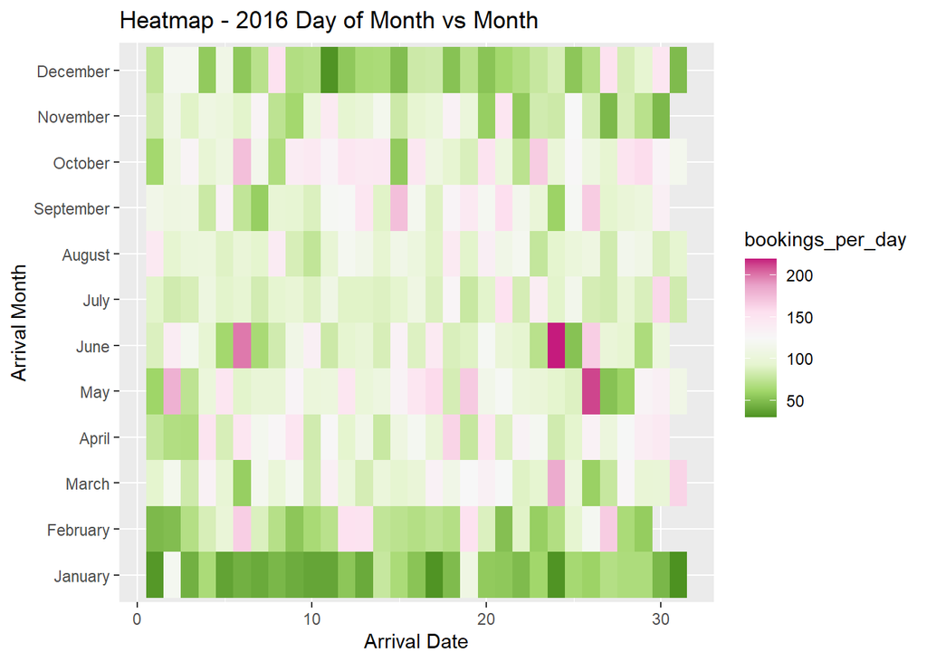

```r
bookings_by_month_day <-
  hotels %>%
    filter(is_canceled == 0 & arrival_date_year == 2016) %>%
      mutate(arrival_date_month = fct_relevel(arrival_date_month,
                                         "January",
                                          "February",
                                          "March",
                                          "April",
                                          "May",
                                          "June",
                                          "July",
                                          "August",
                                          "September",
                                          "October",
                                          "November",
                                          "December")) %>%
          group_by(arrival_date_month,arrival_date_day_of_month) %>%
            summarise(bookings_per_day = n())

ggplot(bookings_by_month_day,aes(x=arrival_date_day_of_month,y=arrival_date_month,fill=bookings_per_day)) +
  geom_tile() +
    ggtitle("Heatmap - 2016 Day of Month vs Month") +
      scale_fill_distiller(palette = 'PiYG') +
        xlab("Arrival Date") +
          ylab("Arrival Month")
```

### 4.2 Hotel Services

#### 4.2.1 Hypothesis Proposed

From the data provided we see there are few additional services that the customer can opt during booking their stay in the hotels. These services are - meal, car parking and other special request. From the hotel services that are present in the data few hypothesis we propose are:

- Customer opting for 1 or more services are less likely to cancel their reservations
- Bookings with higher group members and families are more likely to opt for services
- Families with kids are more likely to opt for meal service during their stay
- Customers of Resort Hotel are more likely to opt for special service requests than City Hotel Customers
- During the holiday seasons number of special requests increases for both resort and city hotels

To check the different hypothesis regarding hotel services we will check the booking and cancellation count for `Resort Hotel` and `City Hotel` against the different services provided. We will create an additional field called `services_offered` in our data set which will indicate if a hotel is providing any additional services to the customer.

```r
hotels$services_offered <- ifelse((hotels$meal != "Undefined" | hotels$required_car_parking_spaces > 0 | hotels$total_of_special_requests > 0), "Yes", "No")
```

On initial exploration we observe that both `Resort Hotel` and `City Hotel` offer 1 or more services and higher number customers tend to opt for these services. We can see the distribution as below

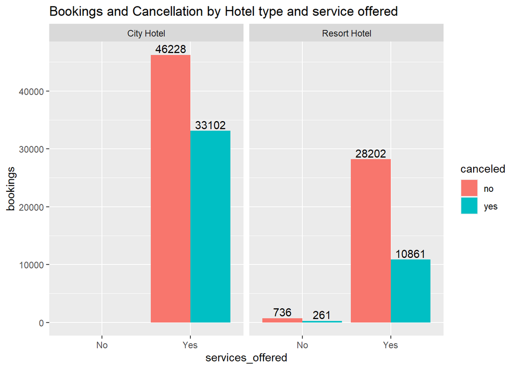

```r
hotel_services <- hotels %>% mutate(canceled = ifelse(is_canceled == 1, "yes", "no")) %>%  group_by(hotel, services_offered, canceled) %>% summarise(bookings = n())

ggplot(data = hotel_services, aes(fill = canceled, x = services_offered, y = bookings)) +
  geom_bar(position="dodge", stat="identity") +
  ggtitle("Bookings and Cancellation by Hotel type and service offered") +
  facet_wrap(~hotel) +
  geom_text(aes(label=bookings), position=position_dodge(width=0.9), vjust=-0.25)
```

We can further check which hotels provide which services

```r
service_table <- hotels %>% mutate(meal_service = ifelse(meal == "Undefined", "no", "yes"),
                                   car_parking = ifelse(required_car_parking_spaces > 0, "yes", "no"),
                                   special_request = ifelse(total_of_special_requests > 0, "yes", "no")) %>%
                select(hotel, meal_service, car_parking, special_request) %>%
                filter(meal_service == "yes", car_parking == "yes", special_request == "yes") %>%
                distinct(hotel, meal_service, car_parking, special_request, .keep_all = TRUE)
kable(service_table, caption = "Service offering by hotel type")
```

Service offering by hotel type

| hotel | meal_service | car_parking | special_request |
| --- | --- | --- | --- |
| Resort Hotel | yes | yes | yes |
| City Hotel | yes | yes | yes |

From the above table we see both `Resort Hotel` and `City Hotel` provide all 3 types of additional services. Now that we have checked our data we check our stated hypothesis to derive actionable strategies.

#### 4.2.2 Analysis and Trends to Answer Key Questions

After the initial exploration of the services data we now check the validity of the five proposed hypothesis

##### Hypothesis 1

**Customer opting for 1 or more services are less likely to cancel their reservations**

We check the percent of customers who cancelled after opting for services

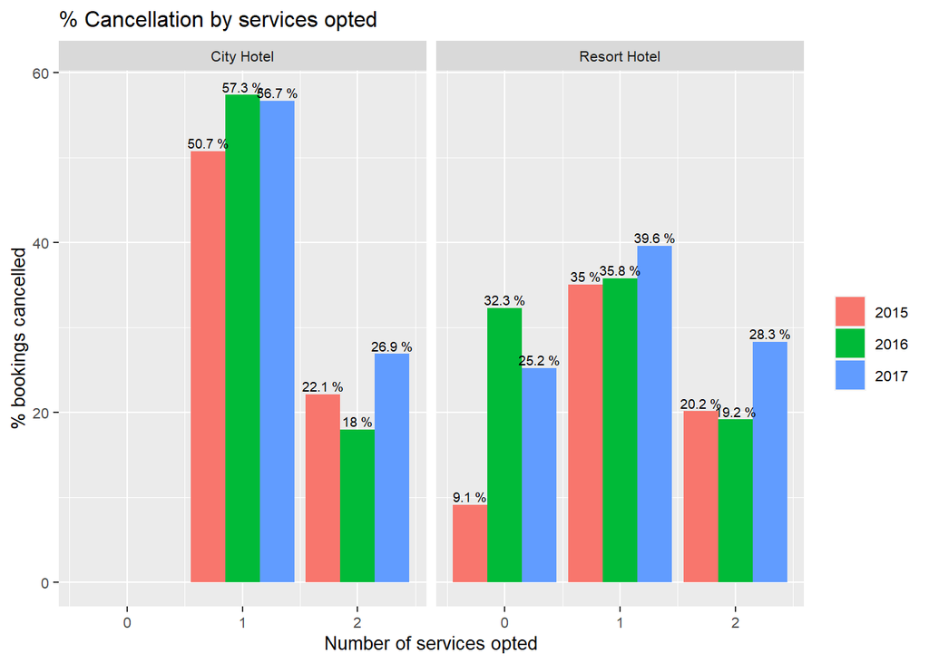

```r
service_count <- hotels %>% mutate(meal_service = ifelse(meal == "Undefined", 0, 1),
                                   car_parking = ifelse(required_car_parking_spaces > 0, 1, 0),
                                   special_request = ifelse(total_of_special_requests > 0, 1, 0),
                                   total_service = meal_service + car_parking + special_request) %>%
                select(hotel, arrival_date_year, total_service, is_canceled) %>% group_by(hotel, arrival_date_year, total_service, is_canceled) %>%
                summarise(bookings = n())

service_total <- service_count %>% group_by(hotel, arrival_date_year, total_service) %>% summarise(total = sum(bookings))

service_pctcancelled <- left_join(service_count, service_total, by = c("hotel", "arrival_date_year", "total_service")) %>% filter(is_canceled == 1) %>%
                        mutate(pct = (bookings/total) * 100) %>% select(hotel, arrival_date_year, total_service, pct)

ggplot(data = service_pctcancelled, aes(fill = as.character(arrival_date_year), x = total_service, y = pct)) +
  geom_bar(position = "dodge", stat = "identity") +
  ggtitle("% Cancellation by services opted") +
  facet_wrap(~hotel) +
  xlab("Number of services opted") +
  ylab("% bookings cancelled") +
  theme(legend.title = element_blank(), text = element_text(size = 10)) +
  geom_text(aes(label=paste(round(pct,1), "%")), size = 2.5, position=position_dodge(width=0.9), vjust=-0.3)
```

From the above plot we can see all `City Hotel` booking have opted for 1 or more services. For `City Hotel` we see people who have opted for 2 services are less likely to cancel their reservation as the cancellation rate drops from 56.7% for people opting 1 service to 26.9% for people opting for 2 services in 2017.

For `Resort Hotel` we see the cancellation rate drops from 39.6% for people opting for 1 service to 28.3% for people opting for 2 services in 2017. In both case of `Resort Hotel` and `City Hotel` 0 cancellations were present for people opting for all 3 services. From the trends observed, our hypothesis hold true. We should promote more additional services to customers to make their booking more attractive.

##### Hypothesis 2

**Bookings with higher group members and families are more likely to opt for services**

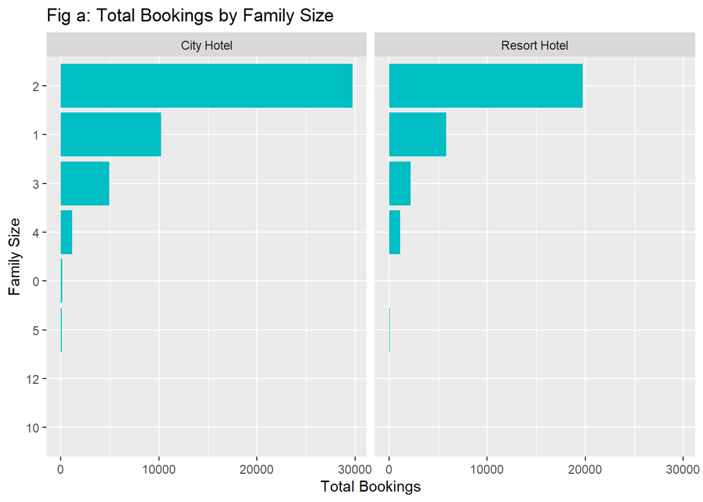

```r
hotels %>% mutate(family_size = adults + children + babies,
                  meal_service = ifelse(meal == "Undefined", 0, 1),
                  total_service = meal_service + required_car_parking_spaces + total_of_special_requests) %>% filter(is.na(family_size) == FALSE, is_canceled == 0) %>%
  group_by(hotel, family_size) %>% summarise(bookings = n()) %>%
  ggplot(aes(x = reorder(family_size, bookings), y = bookings)) +
  geom_bar(stat = "identity", fill = "#00BFC4") +
  facet_wrap(~hotel)+
  coord_flip() +
  scale_y_continuous(name="Total Bookings") +
  scale_x_discrete(name="Family Size") +
  ggtitle("Fig a: Total Bookings by Family Size")
```

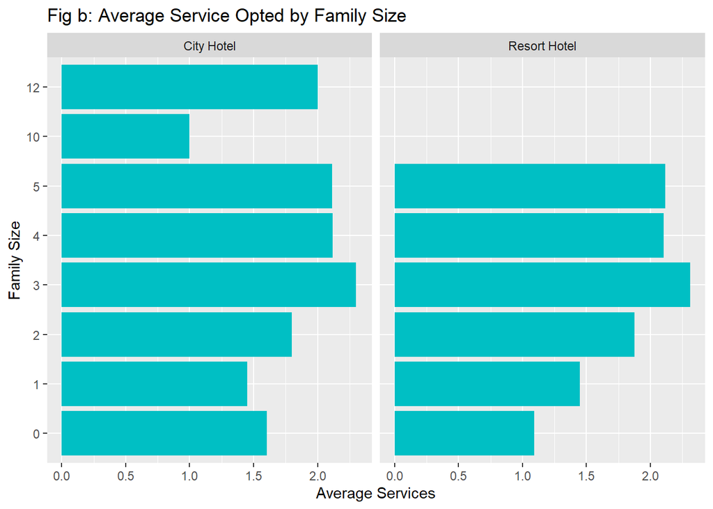

```r
hotels %>% mutate(family_size = adults + children + babies,
                  meal_service = ifelse(meal == "Undefined", 0, 1),
                  total_service = meal_service + required_car_parking_spaces + total_of_special_requests) %>% filter(is.na(family_size) == FALSE, is_canceled == 0) %>%
  group_by(hotel, family_size) %>% summarise(avg_services = mean(total_service, na.rm = TRUE)) %>%
  ggplot(aes(x = reorder(family_size, family_size), y = avg_services)) +
  geom_bar(stat = "identity", fill = "#00BFC4") +
  facet_wrap(~hotel)+
  coord_flip() +
  scale_y_continuous(name="Average Services") +
  scale_x_discrete(name="Family Size") +
  ggtitle("Fig b: Average Service Opted by Family Size")
```

From the above chart we notice that majority of the bookings are done family size of 2 for both resort hotel and city hotel. From the Fig b we note families of size 3 are more likely to opt for more services than other groups. To improve the booking rates we can have deals and packages for services for families with 3 or more.

##### Hypothesis 3

**Families with kids are more likely to opt for greater service during their stay**

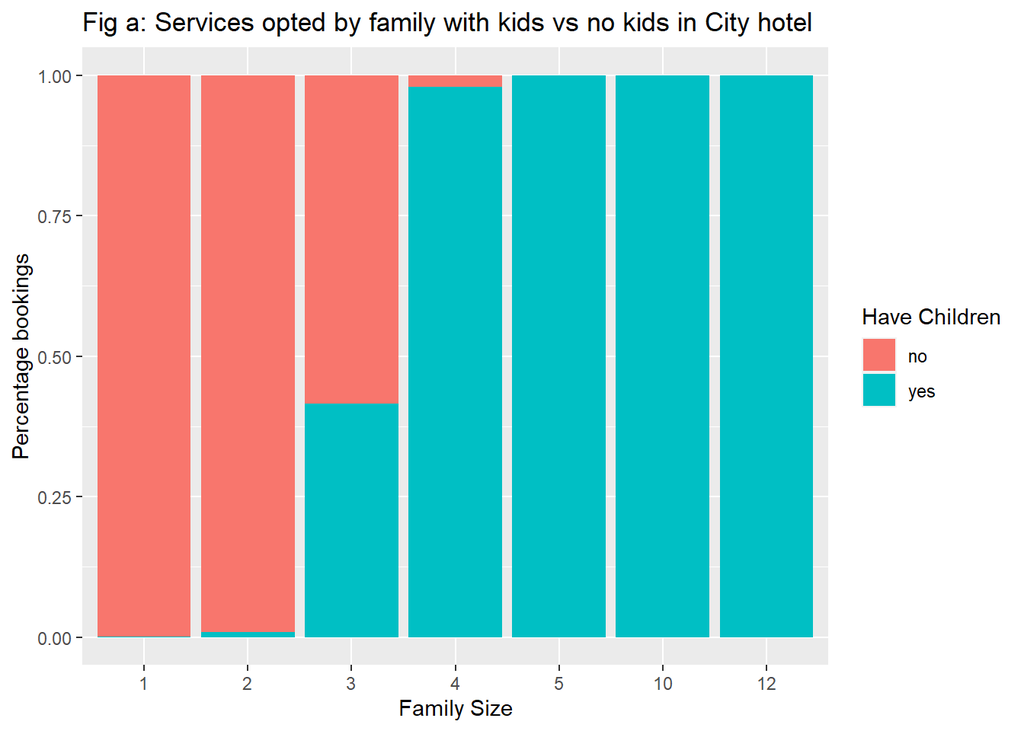

```r
data2 <- hotels %>% mutate(tot_children = ifelse(children + babies > 0, "yes", "no"),
                  family_size = adults + children + babies,
                  meal_service = ifelse(meal == "Undefined", 0, 1),
                  total_service = meal_service + required_car_parking_spaces + total_of_special_requests,
                  stay_duration = stays_in_week_nights + stays_in_weekend_nights) %>%
  filter(is_canceled == 0, total_service > 0, family_size > 0) %>% group_by(hotel, family_size, tot_children) %>% summarise(booking = n())

ggplot(data = data2[data2$hotel == "City Hotel",], aes(x = reorder(as.character(family_size), family_size), y = booking, fill = tot_children)) +
  geom_col(position = "fill") +
  scale_y_continuous(name="Percentage bookings") +
  xlab("Family Size") +
  ggtitle("Fig a: Services opted by family with kids vs no kids in City hotel") +
  labs(fill = "Have Children")
```

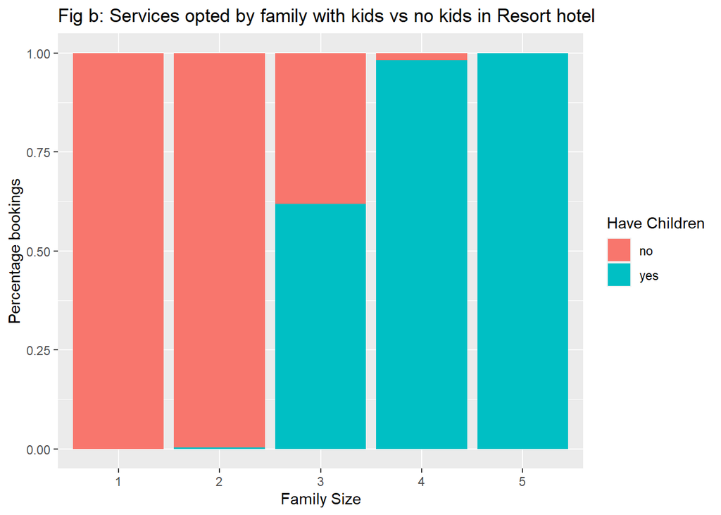

```r
ggplot(data = data2[data2$hotel == "Resort Hotel",], aes(x = reorder(as.character(family_size), family_size), y = booking, fill = tot_children)) +
  geom_col(position = "fill") +
  scale_y_continuous(name="Percentage bookings") +
  xlab("Family Size") +
  ggtitle("Fig b: Services opted by family with kids vs no kids in Resort hotel")+
  labs(fill = "Have Children")
```

From the above stacked barplot in **fig a** we observe that in City hotel family sizes of more than 3 tend to have children, but for family sizes 3 or less people without children are more likely to opt for services. Whereas in Resort hotel the maximum group size is 5 and groups of 3 or more tends to have kids with them and they opt for more services. To further understand the number of services opted by families with kids to explore **fig c** and **fig d**.

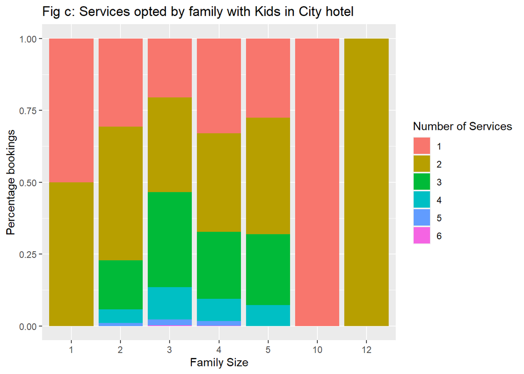

```r
fam_kids <-   hotels %>% mutate(tot_children = ifelse(children + babies > 0, "yes", "no"),
                  family_size = adults + children + babies,
                  meal_service = ifelse(meal == "Undefined", 0, 1),
                  total_service = meal_service + required_car_parking_spaces + total_of_special_requests,
                  stay_duration = stays_in_week_nights + stays_in_weekend_nights) %>%
  filter(is_canceled == 0) %>% group_by(hotel, total_service, family_size, tot_children) %>% summarise(booking = n()) %>% filter(tot_children == "yes")


ggplot(data = fam_kids[fam_kids$hotel == "City Hotel",], aes(x = reorder(as.character(family_size), family_size), y = booking, fill = as.character(total_service))) +
  geom_col(position = "fill") +
  scale_y_continuous(name="Percentage bookings") +
  xlab("Family Size") +
  ggtitle("Fig c: Services opted by family with Kids in City hotel") +
  labs(fill = "Number of Services")
```

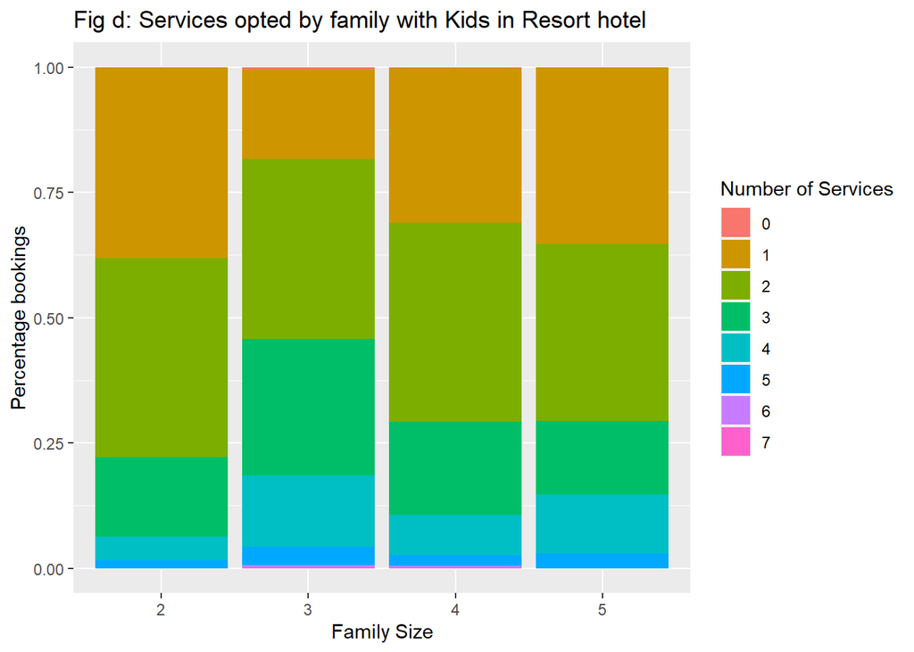

```r
ggplot(data = fam_kids[fam_kids$hotel == "Resort Hotel",], aes(x = reorder(as.character(family_size), family_size), y = booking, fill = as.character(total_service))) +
  geom_col(position = "fill") +
  scale_y_continuous(name="Percentage bookings") +
  xlab("Family Size") +
  ggtitle("Fig d: Services opted by family with Kids in Resort hotel") +
  labs(fill = "Number of Services")
```

From **fig c** we notice most families with kids tend to opt for 1 or 2 services, but family sizes of 3 tend to opt for higher number of services than 2 in City hotels. From **fig d** a similar trend is being followed in resort hotel.

##### Hypothesis 4

**Customers of Resort Hotel are more likely to opt for special service requests than City Hotel Customers**

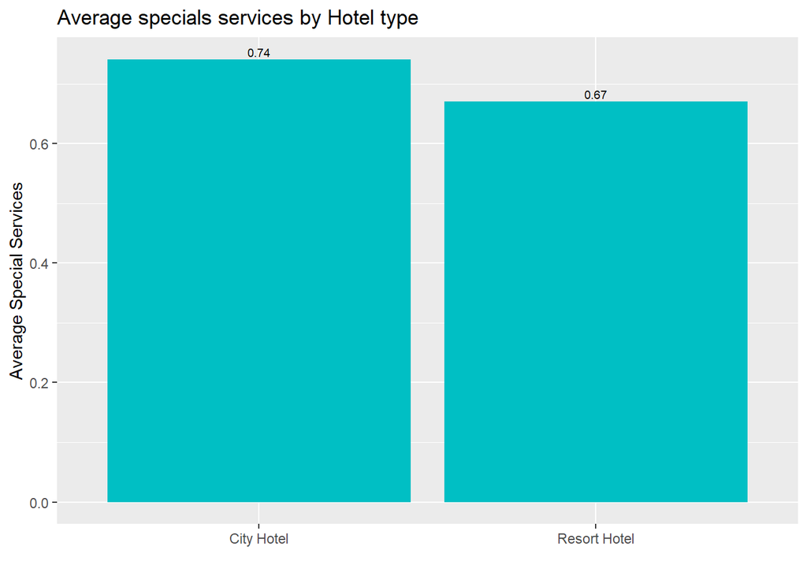

```r
other_services <- hotels %>% filter(is_canceled == 0) %>% group_by(hotel) %>% summarise(avg_special_service = mean(total_of_special_requests))

ggplot(data = other_services, aes(x = hotel, y = avg_special_service)) +
  geom_bar(stat = "identity", fill = "#00BFC4") +
  ggtitle("Average specials services by Hotel type") +
  xlab("") +
  ylab("Average Special Services") +
  geom_text(aes(label= round(avg_special_service,2)), size = 2.5, position=position_dodge(width=0.9), vjust=-0.3)
```

From the above plot we notice our proposed hypothesis doesn’t hold true. On contrary people are opting for more special services in city hotel than in resort hotel. In our hotel data we don’t have much details regarding the type of special services request by customers. Based on the observation we can propose to provide deals on special services to City hotel customer to boost booking rate.

##### Hypothesis 5

**During the holiday seasons number of special requests increases for both resort and city hotels**

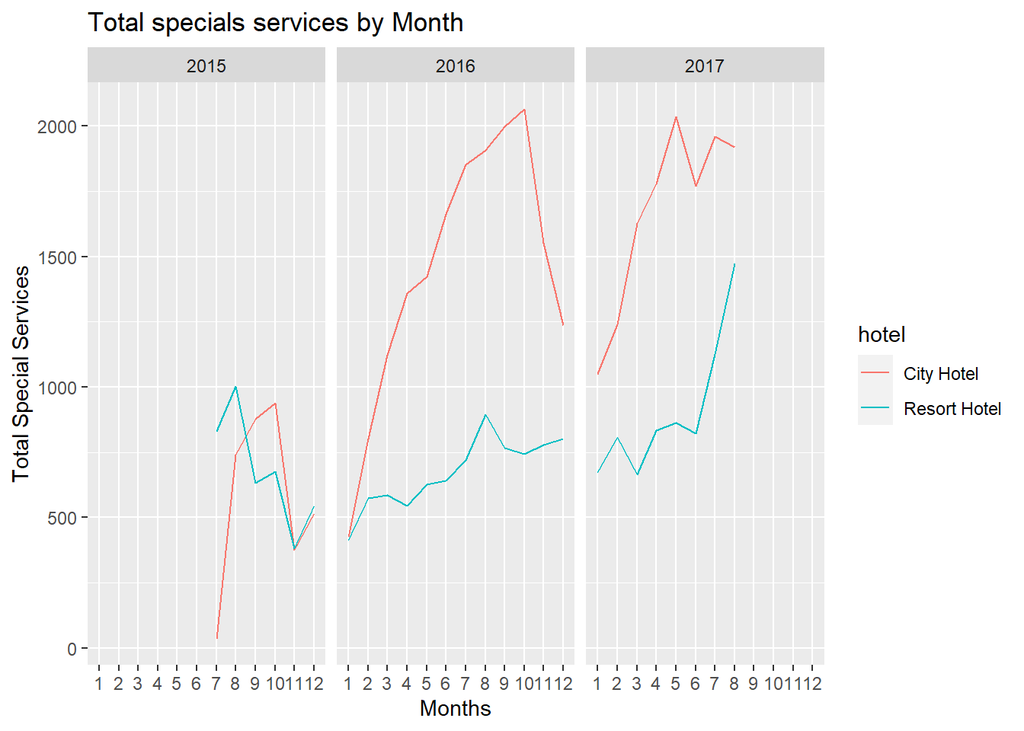

```r
services_holiday <- hotels %>% filter(is_canceled == 0) %>%
  mutate(month_date = lubridate::mdy(paste(arrival_date_month, "01",arrival_date_year, sep = "/")),
         month = match(arrival_date_month, month.name)) %>%
  group_by(hotel, arrival_date_year, month) %>%
  summarise(special_req = sum(total_of_special_requests),
            avg_special_req = mean(total_of_special_requests),
            bookings = n())

ggplot(data = services_holiday, aes(x = month, y = special_req, group = hotel)) +
  geom_line(aes(color = hotel)) +
  facet_wrap(~arrival_date_year) +
  scale_x_discrete("Months", limits = c("1", "2", "3", "4", "5", "6", "7", "8", "9", "10", "11", "12")) +
  ggtitle("Total specials services by Month") +
  xlab("Month-Year") +
  ylab("Total Special Services")
```

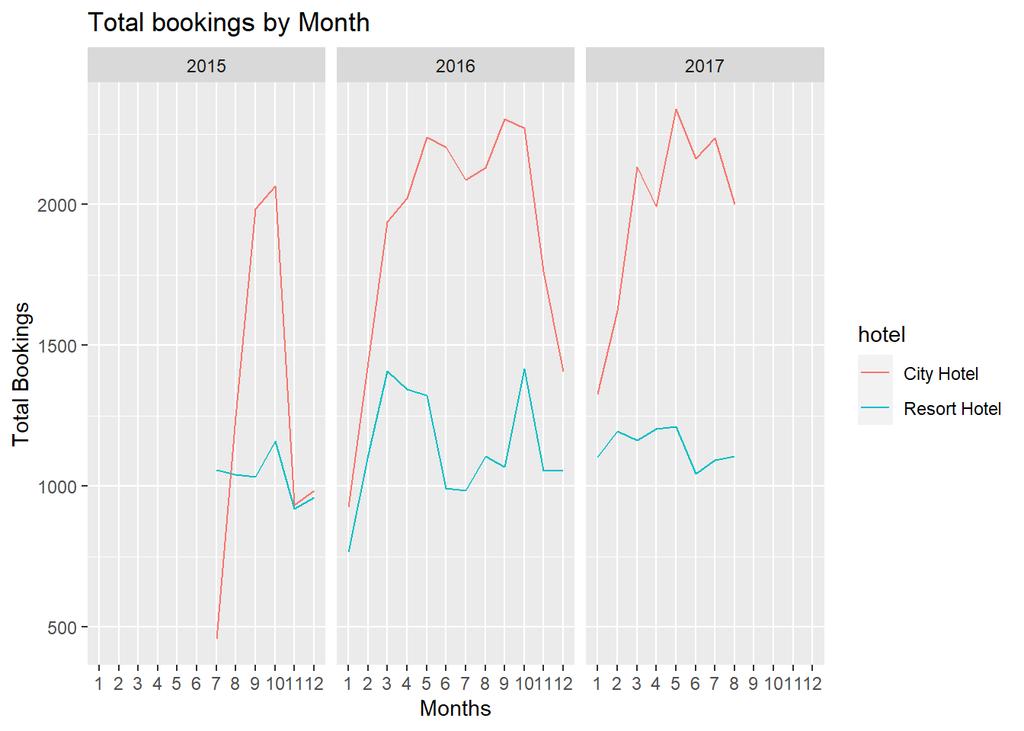

```r
ggplot(data = services_holiday, aes(x = month, y = bookings, group = hotel)) +
  geom_line(aes(color = hotel)) +
  facet_wrap(~arrival_date_year) +
  scale_x_discrete("Months", limits = c("1", "2", "3", "4", "5", "6", "7", "8", "9", "10", "11", "12")) +
  ggtitle("Total bookings by Month") +
  xlab("Month-Year") +
  ylab("Total Bookings")
```

To improve our booking rates we can provide special offers on such services during the peak booking months.

##### Hypothesis 6

**Bed and Breakfast is the most popular meal type opted by customers in both types of Hotel**

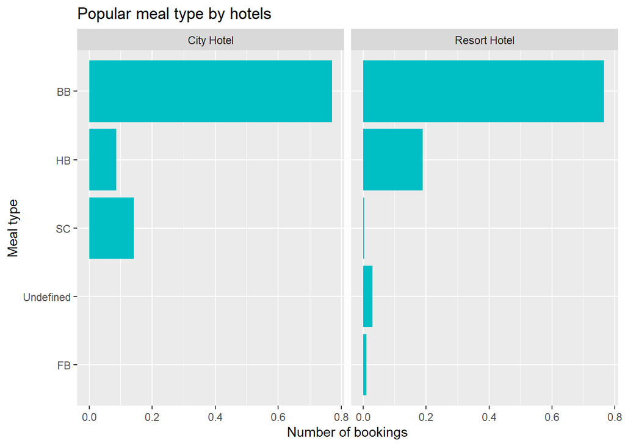

```r
meal_type <- hotels %>% filter(is_canceled == 0) %>% group_by(hotel, meal) %>% summarise(bookings = n())

total_booking <- hotels %>% filter(is_canceled == 0) %>% group_by(hotel) %>% summarise(bookings_tot = n())

meal_type_pct <- left_join(meal_type, total_booking, by = "hotel")

ggplot(data = meal_type_pct, aes(x= reorder(meal, bookings), y = (bookings/bookings_tot))) +
  geom_bar(stat = "identity", fill = "#00BFC4") +
  facet_wrap(~hotel)+
  coord_flip() +
  scale_y_continuous(name="Number of bookings") +
  scale_x_discrete(name="Meal type") +
  ggtitle("Popular meal type by hotels")
```

From this we can strategize to provide more deals on meal packages to resort customers to boost booking rates.

### 4.3 Customer Demography features

#### 4.3.1 Hypothesis Proposed

One of the key inferences that we get from the data is that majority of tourist who book the hotel stay are from Portugal which is the home country followed by tourists from Great Britain which can be seen below

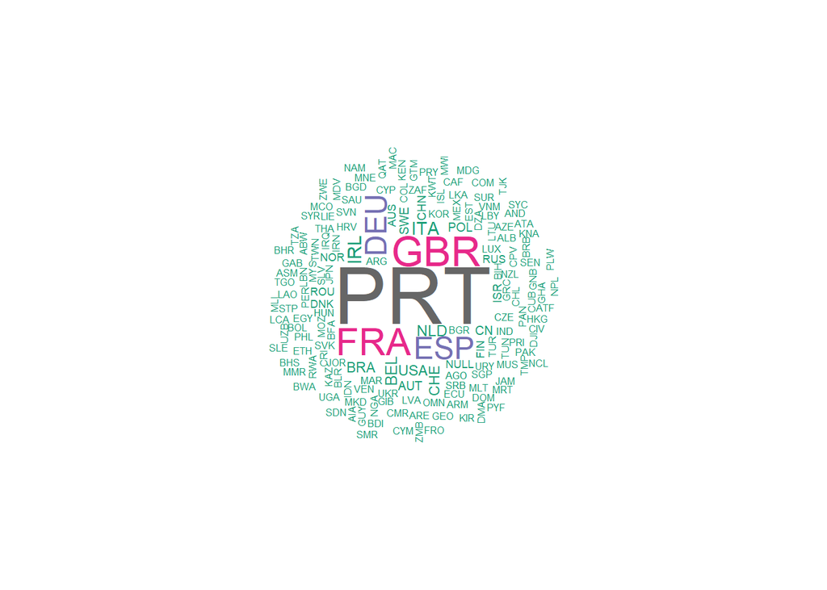

```r
hotels_country <- hotels %>% select(hotel, country, arrival_date_year, is_canceled) %>% filter(is_canceled == 0) %>%
                  group_by(country) %>% summarise(bookings = n()) %>% arrange(desc(bookings))

wordcloud(words = hotels_country$country, freq = hotels_country$bookings, min.freq = 1, max.words=200, random.order=FALSE, rot.per=0.35,            colors=brewer.pal(8, "Dark2"))
```

```r
is_family <- ((hotels$babies> 0  | hotels$children > 0) & hotels$adults > 0)
hotels$is_family <- is_family
booking_duration <- hotels$stays_in_weekend_nights + hotels$stays_in_week_nights
hotels$booking_duration <- booking_duration
```

Making a new variable that includes countries that had the most visitors. This has top 6 countries named and rest of the countries as others.

```r
hotels$new_country <- hotels$country
hotels$new_country[hotels$new_country != "PRT" & hotels$new_country != "GBR"
                   & hotels$new_country != "FRA" & hotels$new_country != "ESP"
                   & hotels$new_country != "DEU" & hotels$new_country != "ITA"] <- "Others"
hotels$new_country[hotels$new_country == "PRT"] <- "Portugal"
hotels$new_country[hotels$new_country == "GBR"] <- "Great Britain"
hotels$new_country[hotels$new_country == "FRA"] <- "France"
hotels$new_country[hotels$new_country == "ESP"] <- "Spain"
hotels$new_country[hotels$new_country == "DEU"] <- "Germany"
hotels$new_country[hotels$new_country == "ITA"] <- "Italy"
```

#### 4.3.2 Analysis and Trends to Answer Key Questions

##### Hypothesis 1

**The customers who are part of a group or group with children tend to have a longer stay**

The aim is to identify whether the the visitors will stay longer as the no. of visitors in a booking would increase. There are two plots, one for just group size and other for groups which have children i.e. visitors who are part of a family.

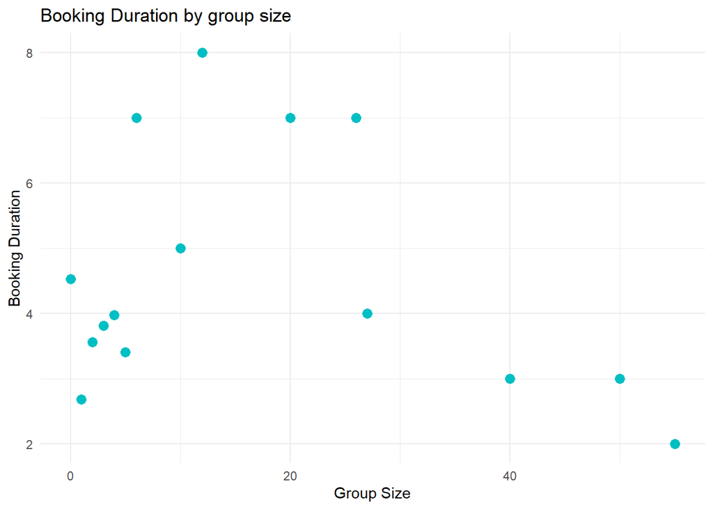

```r
hotels %>% mutate(group_size_n = adults+children+babies,total_stay = stays_in_weekend_nights+stays_in_week_nights)%>%
group_by(group_size_n)%>%
summarise(average_booking = mean(total_stay))  %>%
ggplot(aes(group_size_n,average_booking)) +
geom_point(color = "#00BFC4",size = 3) +
labs(title="Booking Duration by group size", x="Group Size", y="Booking Duration")+
  theme_minimal()
```

**For groups with children:**

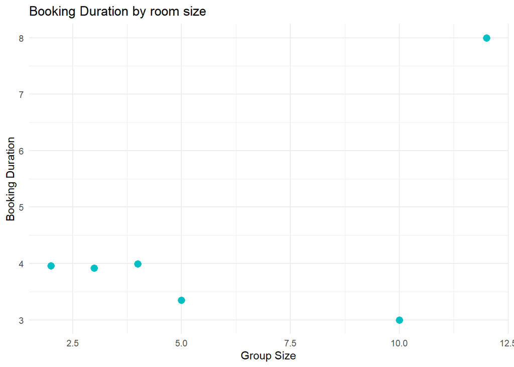

```r
hotels %>% mutate(group_size_n = adults+children+babies,total_stay = stays_in_weekend_nights+stays_in_week_nights)%>%
filter(is_family == TRUE)  %>%
group_by(group_size_n)%>%
summarise(average_booking = mean(total_stay))  %>%
ggplot(aes(group_size_n,average_booking )) +
geom_point(color = "#00BFC4",size= 3) +
labs(title="Booking Duration by room size", x="Group Size", y="Booking Duration")+
  theme_minimal()
```